```r
library(ggplot2)
library(corrplot)
library(tidyverse)
library(dplyr)
library(caret)
library(nnet)
library(NeuralNetTools)
library(gmodels)
library(tibble)
```

```r
nn <- read.csv("wdbc.csv")
```

```r
str(nn)
```

```
## 'data.frame':    569 obs. of  32 variables:
##  $ ID          : int  842302 842517 84300903 84348301 84358402 843786 844359 84458202 844981 84501001 ...
##  $ diagnosis   : chr  "M" "M" "M" "M" ...
##  $ radius      : num  18 20.6 19.7 11.4 20.3 ...
##  $ texture     : num  10.4 17.8 21.2 20.4 14.3 ...
##  $ perimeter   : num  122.8 132.9 130 77.6 135.1 ...
##  $ area        : num  1001 1326 1203 386 1297 ...
##  $ smoothness  : num  0.1184 0.0847 0.1096 0.1425 0.1003 ...
##  $ compactness : num  0.2776 0.0786 0.1599 0.2839 0.1328 ...
##  $ concavity   : num  0.3001 0.0869 0.1974 0.2414 0.198 ...
##  $ concave     : num  0.1471 0.0702 0.1279 0.1052 0.1043 ...
##  $ symmetry    : num  0.242 0.181 0.207 0.26 0.181 ...
##  $ fractal     : num  0.0787 0.0567 0.06 0.0974 0.0588 ...
##  $ radius2     : num  1.095 0.543 0.746 0.496 0.757 ...
##  $ texture2    : num  0.905 0.734 0.787 1.156 0.781 ...
```

[output cut: 18 more lines]

We need to ensure that the target variable is in factor.

```r
# Transforming the target variable that I will use to submit to the categorical algorithm into factors and removing the ID and odd target variable
diagnosis = factor(nn$diagnosis, levels = c("M", "B"), labels = c("M", "B"))
data = nn[,-1]
data = data[,-1]

# Adding the newly re-coded variable to the data
nndata <- cbind(diagnosis, data)
nndata
```

| diagnosis | radius | texture | perimeter | area | smoothness | compactness | concavity | concave | symmetry | fractal | radius2 | texture2 | perimeter2 | area2 | smoothness2 | compactness2 | concavity2 | concave2 | symmetry2 | fractal2 | radius3 | texture3 | perimeter3 | area3 | smoothness3 | compactness3 | concavity3 | concave3 | symmetry3 | … |
| --- | --- | --- | --- | --- | --- | --- | --- | --- | --- | --- | --- | --- | --- | --- | --- | --- | --- | --- | --- | --- | --- | --- | --- | --- | --- | --- | --- | --- | --- | --- |
| M | 17.990 | 10.38 | 122.80 | 1001.0 | 0.11840 | 0.27760 | 0.3001000 | 0.147100 | 0.2419 | 0.07871 | 1.0950 | 0.9053 | 8.5890 | 153.400 | 0.006399 | 0.049040 | 0.0537300 | 0.015870 | 0.030030 | 0.0061930 | 25.380 | 17.33 | 184.60 | 2019.0 | 0.16220 | 0.66560 | 0.711900 | 0.265400 | 0.4601 | … |
| M | 20.570 | 17.77 | 132.90 | 1326.0 | 0.08474 | 0.07864 | 0.0869000 | 0.070170 | 0.1812 | 0.05667 | 0.5435 | 0.7339 | 3.3980 | 74.080 | 0.005225 | 0.013080 | 0.0186000 | 0.013400 | 0.013890 | 0.0035320 | 24.990 | 23.41 | 158.80 | 1956.0 | 0.12380 | 0.18660 | 0.241600 | 0.186000 | 0.2750 | … |
| M | 19.690 | 21.25 | 130.00 | 1203.0 | 0.10960 | 0.15990 | 0.1974000 | 0.127900 | 0.2069 | 0.05999 | 0.7456 | 0.7869 | 4.5850 | 94.030 | 0.006150 | 0.040060 | 0.0383200 | 0.020580 | 0.022500 | 0.0045710 | 23.570 | 25.53 | 152.50 | 1709.0 | 0.14440 | 0.42450 | 0.450400 | 0.243000 | 0.3613 | … |
| M | 11.420 | 20.38 | 77.58 | 386.1 | 0.14250 | 0.28390 | 0.2414000 | 0.105200 | 0.2597 | 0.09744 | 0.4956 | 1.1560 | 3.4450 | 27.230 | 0.009110 | 0.074580 | 0.0566100 | 0.018670 | 0.059630 | 0.0092080 | 14.910 | 26.50 | 98.87 | 567.7 | 0.20980 | 0.86630 | 0.686900 | 0.257500 | 0.6638 | … |
| M | 20.290 | 14.34 | 135.10 | 1297.0 | 0.10030 | 0.13280 | 0.1980000 | 0.104300 | 0.1809 | 0.05883 | 0.7572 | 0.7813 | 5.4380 | 94.440 | 0.011490 | 0.024610 | 0.0568800 | 0.018850 | 0.017560 | 0.0051150 | 22.540 | 16.67 | 152.20 | 1575.0 | 0.13740 | 0.20500 | 0.400000 | 0.162500 | 0.2364 | … |
| M | 12.450 | 15.70 | 82.57 | 477.1 | 0.12780 | 0.17000 | 0.1578000 | 0.080890 | 0.2087 | 0.07613 | 0.3345 | 0.8902 | 2.2170 | 27.190 | 0.007510 | 0.033450 | 0.0367200 | 0.011370 | 0.021650 | 0.0050820 | 15.470 | 23.75 | 103.40 | 741.6 | 0.17910 | 0.52490 | 0.535500 | 0.174100 | 0.3985 | … |
| M | 18.250 | 19.98 | 119.60 | 1040.0 | 0.09463 | 0.10900 | 0.1127000 | 0.074000 | 0.1794 | 0.05742 | 0.4467 | 0.7732 | 3.1800 | 53.910 | 0.004314 | 0.013820 | 0.0225400 | 0.010390 | 0.013690 | 0.0021790 | 22.880 | 27.66 | 153.20 | 1606.0 | 0.14420 | 0.25760 | 0.378400 | 0.193200 | 0.3063 | … |
| M | 13.710 | 20.83 | 90.20 | 577.9 | 0.11890 | 0.16450 | 0.0936600 | 0.059850 | 0.2196 | 0.07451 | 0.5835 | 1.3770 | 3.8560 | 50.960 | 0.008805 | 0.030290 | 0.0248800 | 0.014480 | 0.014860 | 0.0054120 | 17.060 | 28.14 | 110.60 | 897.0 | 0.16540 | 0.36820 | 0.267800 | 0.155600 | 0.3196 | … |
| M | 13.000 | 21.82 | 87.50 | 519.8 | 0.12730 | 0.19320 | 0.1859000 | 0.093530 | 0.2350 | 0.07389 | 0.3063 | 1.0020 | 2.4060 | 24.320 | 0.005731 | 0.035020 | 0.0355300 | 0.012260 | 0.021430 | 0.0037490 | 15.490 | 30.73 | 106.20 | 739.3 | 0.17030 | 0.54010 | 0.539000 | 0.206000 | 0.4378 | … |
| M | 12.460 | 24.04 | 83.97 | 475.9 | 0.11860 | 0.23960 | 0.2273000 | 0.085430 | 0.2030 | 0.08243 | 0.2976 | 1.5990 | 2.0390 | 23.940 | 0.007149 | 0.072170 | 0.0774300 | 0.014320 | 0.017890 | 0.0100800 | 15.090 | 40.68 | 97.65 | 711.4 | 0.18530 | 1.05800 | 1.105000 | 0.221000 | 0.4366 | … |

[output cut: 559 more lines]

```r
summary(nndata)
```

```
##  diagnosis     radius          texture        perimeter           area
##  M:212     Min.   : 6.981   Min.   : 9.71   Min.   : 43.79   Min.   : 143.5
##  B:357     1st Qu.:11.700   1st Qu.:16.17   1st Qu.: 75.17   1st Qu.: 420.3
##            Median :13.370   Median :18.84   Median : 86.24   Median : 551.1
##            Mean   :14.127   Mean   :19.29   Mean   : 91.97   Mean   : 654.9
##            3rd Qu.:15.780   3rd Qu.:21.80   3rd Qu.:104.10   3rd Qu.: 782.7
##            Max.   :28.110   Max.   :39.28   Max.   :188.50   Max.   :2501.0
##    smoothness       compactness        concavity          concave
##  Min.   :0.05263   Min.   :0.01938   Min.   :0.00000   Min.   :0.00000
##  1st Qu.:0.08637   1st Qu.:0.06492   1st Qu.:0.02956   1st Qu.:0.02031
##  Median :0.09587   Median :0.09263   Median :0.06154   Median :0.03350
##  Mean   :0.09636   Mean   :0.10434   Mean   :0.08880   Mean   :0.04892
##  3rd Qu.:0.10530   3rd Qu.:0.13040   3rd Qu.:0.13070   3rd Qu.:0.07400
##  Max.   :0.16340   Max.   :0.34540   Max.   :0.42680   Max.   :0.20120
##     symmetry         fractal           radius2          texture2
##  Min.   :0.1060   Min.   :0.04996   Min.   :0.1115   Min.   :0.3602
##  1st Qu.:0.1619   1st Qu.:0.05770   1st Qu.:0.2324   1st Qu.:0.8339
##  Median :0.1792   Median :0.06154   Median :0.3242   Median :1.1080
##  Mean   :0.1812   Mean   :0.06280   Mean   :0.4052   Mean   :1.2169
##  3rd Qu.:0.1957   3rd Qu.:0.06612   3rd Qu.:0.4789   3rd Qu.:1.4740
##  Max.   :0.3040   Max.   :0.09744   Max.   :2.8730   Max.   :4.8850
##    perimeter2         area2          smoothness2        compactness2
##  Min.   : 0.757   Min.   :  6.802   Min.   :0.001713   Min.   :0.002252
##  1st Qu.: 1.606   1st Qu.: 17.850   1st Qu.:0.005169   1st Qu.:0.013080
##  Median : 2.287   Median : 24.530   Median :0.006380   Median :0.020450
##  Mean   : 2.866   Mean   : 40.337   Mean   :0.007041   Mean   :0.025478
##  3rd Qu.: 3.357   3rd Qu.: 45.190   3rd Qu.:0.008146   3rd Qu.:0.032450
##  Max.   :21.980   Max.   :542.200   Max.   :0.031130   Max.   :0.135400
##    concavity2         concave2          symmetry2           fractal2
##  Min.   :0.00000   Min.   :0.000000   Min.   :0.007882   Min.   :0.0008948
##  1st Qu.:0.01509   1st Qu.:0.007638   1st Qu.:0.015160   1st Qu.:0.0022480
##  Median :0.02589   Median :0.010930   Median :0.018730   Median :0.0031870
##  Mean   :0.03189   Mean   :0.011796   Mean   :0.020542   Mean   :0.0037949
##  3rd Qu.:0.04205   3rd Qu.:0.014710   3rd Qu.:0.023480   3rd Qu.:0.0045580
##  Max.   :0.39600   Max.   :0.052790   Max.   :0.078950   Max.   :0.0298400
##     radius3         texture3       perimeter3         area3
##  Min.   : 7.93   Min.   :12.02   Min.   : 50.41   Min.   : 185.2
##  1st Qu.:13.01   1st Qu.:21.08   1st Qu.: 84.11   1st Qu.: 515.3
##  Median :14.97   Median :25.41   Median : 97.66   Median : 686.5
##  Mean   :16.27   Mean   :25.68   Mean   :107.26   Mean   : 880.6
##  3rd Qu.:18.79   3rd Qu.:29.72   3rd Qu.:125.40   3rd Qu.:1084.0
##  Max.   :36.04   Max.   :49.54   Max.   :251.20   Max.   :4254.0
##   smoothness3       compactness3       concavity3        concave3
##  Min.   :0.07117   Min.   :0.02729   Min.   :0.0000   Min.   :0.00000
##  1st Qu.:0.11660   1st Qu.:0.14720   1st Qu.:0.1145   1st Qu.:0.06493
##  Median :0.13130   Median :0.21190   Median :0.2267   Median :0.09993
##  Mean   :0.13237   Mean   :0.25427   Mean   :0.2722   Mean   :0.11461
##  3rd Qu.:0.14600   3rd Qu.:0.33910   3rd Qu.:0.3829   3rd Qu.:0.16140
##  Max.   :0.22260   Max.   :1.05800   Max.   :1.2520   Max.   :0.29100
##    symmetry3         fractal3
##  Min.   :0.1565   Min.   :0.05504
##  1st Qu.:0.2504   1st Qu.:0.07146
##  Median :0.2822   Median :0.08004
##  Mean   :0.2901   Mean   :0.08395
##  3rd Qu.:0.3179   3rd Qu.:0.09208
##  Max.   :0.6638   Max.   :0.20750
```

```r
prop.table(table(nndata$diagnosis))
```

```
##
##         M         B
## 0.3725835 0.6274165
```

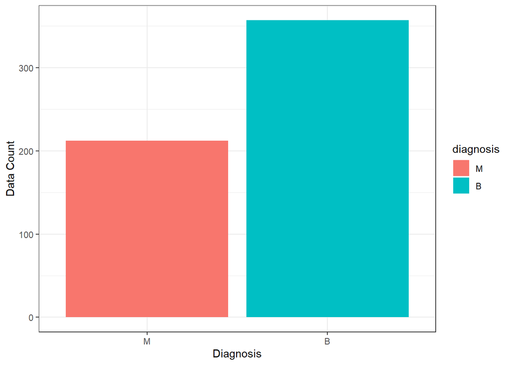

```r
ggplot(nndata, aes(x=diagnosis, fill = diagnosis))+
  theme_bw()+
  geom_bar()+
  labs(x = "Diagnosis", y = "Data Count")
```

## Density Plot

Here we will observe where the majority of the data lies in the cancer dataset as far as diagnosis is concerned.

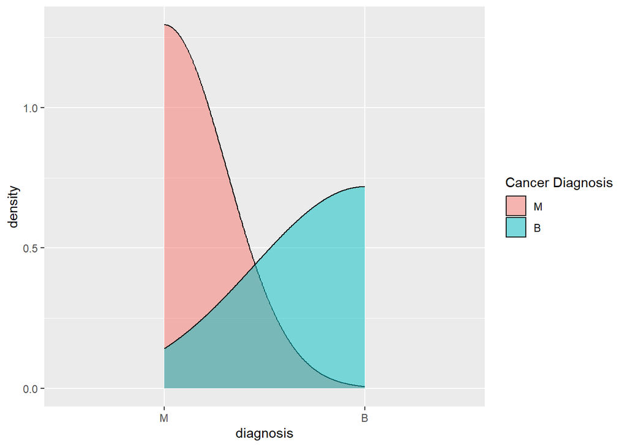

```r
# Density graph for TBSA (Total burn surface area)
ggplot(nndata, aes(x = diagnosis, fill = diagnosis)) +
  geom_density(alpha=0.5) +
  scale_fill_discrete(name = "Cancer Diagnosis", labels = c("M", "B"))
```

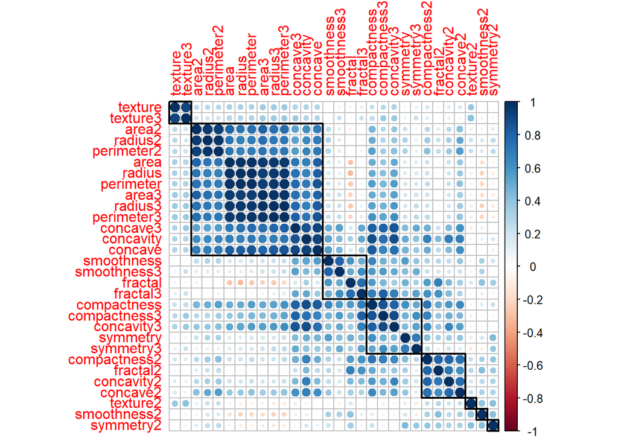

```r
corr_mat <- cor(nndata[,2:ncol(nndata)])
corrplot(corr_mat, order = "hclust", tl.cex = 1, addrect = 8)
```

```r
nndata %>%
    summarise_all(
        funs(sum(is.na(.)))
    )
```

| diagnosis | radius | texture | perimeter | area | smoothness | compactness | concavity | concave | symmetry | fractal | radius2 | texture2 | perimeter2 | area2 | smoothness2 | compactness2 | concavity2 | concave2 | symmetry2 | fractal2 | radius3 | texture3 | perimeter3 | area3 | smoothness3 | compactness3 | concavity3 | concave3 | symmetry3 | … |
| --- | --- | --- | --- | --- | --- | --- | --- | --- | --- | --- | --- | --- | --- | --- | --- | --- | --- | --- | --- | --- | --- | --- | --- | --- | --- | --- | --- | --- | --- | --- |
| 0 | 0 | 0 | 0 | 0 | 0 | 0 | 0 | 0 | 0 | 0 | 0 | 0 | 0 | 0 | 0 | 0 | 0 | 0 | 0 | 0 | 0 | 0 | 0 | 0 | 0 | 0 | 0 | 0 | 0 | … |

## Splitting the data set into Train and Test with 60 and 40 percent respectively

```r
index <- sample(2, nrow(nndata), replace=TRUE, prob = c(0.60, 0.40))
traindata <- nndata[index==1, ]
testdata <- nndata[index==2, ]
```

## Create Neural network model

```r
model_nnet <- nnet(diagnosis ~ ., data = traindata, size=15, rang = 1, decay = 8e-4, maxit = 200)
```

## Plot a neural interpretation diagram for a neural network object

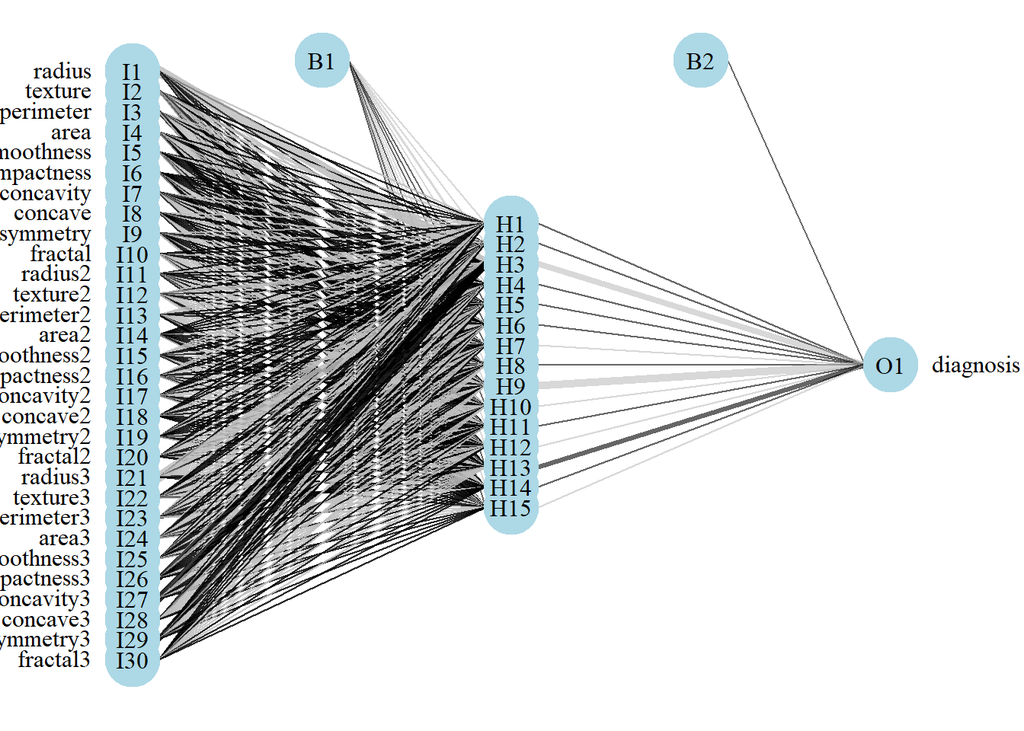

```r
par(mar = numeric(4), family = 'serif')
plotnet(model_nnet, alpha = 0.6)
```

## Predict

```r
pred_nnet <- predict(model_nnet, testdata,type = c("class"))
```

## Accuracy

```r
accuracy <- sum(pred_nnet == testdata$diagnosis)/nrow(testdata)
accuracy
```

```
## [1] 0.9489362
```

## Create cross table to summarize the result

```r
CrossTable(testdata$diagnosis, pred_nnet, prop.chisq = FALSE,
           prop.c = FALSE, prop.r = FALSE, dnn = c("Actual diagnosis",
                                                   "Predicted diagnosis"))
```

```
##
##
##    Cell Contents
## |-------------------------|
## |                       N |
## |         N / Table Total |
## |-------------------------|
##
##
## Total Observations in Table:  235
##
##
##                  | Predicted diagnosis
## Actual diagnosis |         B |         M | Row Total |
## -----------------|-----------|-----------|-----------|
##                M |         4 |        90 |        94 |
##                  |     0.017 |     0.383 |           |
## -----------------|-----------|-----------|-----------|
##                B |       133 |         8 |       141 |
##                  |     0.566 |     0.034 |           |
## -----------------|-----------|-----------|-----------|
##     Column Total |       137 |        98 |       235 |
## -----------------|-----------|-----------|-----------|
##
##
```

```r
pred_nnet = factor(pred_nnet, levels = c("M", "B"), labels = c("M", "B"))
cm_nnet <- confusionMatrix(pred_nnet, testdata$diagnosis, positive = "M")
cm_nnet
```

```
## Confusion Matrix and Statistics
##
##           Reference
## Prediction   M   B
##          M  90   8
##          B   4 133
##
##                Accuracy : 0.9489
##                  95% CI : (0.9125, 0.9733)
##     No Information Rate : 0.6
##     P-Value [Acc > NIR] : <2e-16
##
##                   Kappa : 0.8944
##
##  Mcnemar's Test P-Value : 0.3865
##
##             Sensitivity : 0.9574
##             Specificity : 0.9433
##          Pos Pred Value : 0.9184
##          Neg Pred Value : 0.9708
##              Prevalence : 0.4000
##          Detection Rate : 0.3830
##    Detection Prevalence : 0.4170
##       Balanced Accuracy : 0.9504
##
##        'Positive' Class : M
##
```

Next things to try:

use unbalanced techinques (oversampling, SMOTE…) previously to apply the models

modify models to use a different metric rather than ROC (auc) which takes in consideration the best threshold

Try different stacking models

## Relative importance of input variables in neural networks using Garson’s algorithm

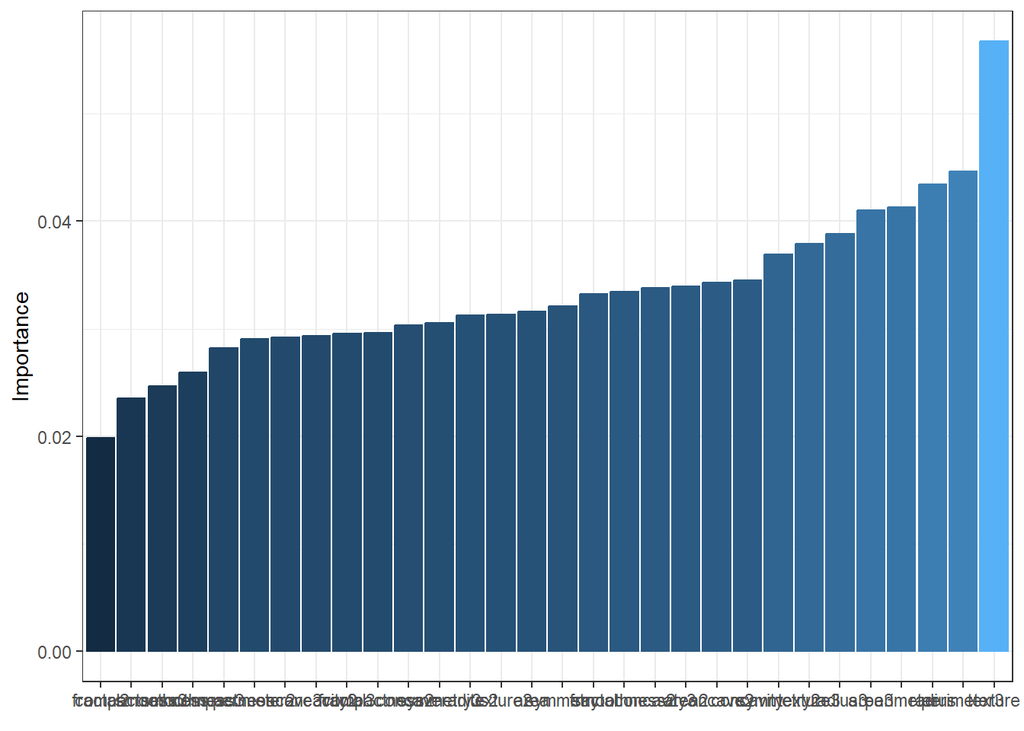

```r
garson(model_nnet)
```

[figure not shown]

```r
lekprofile(model_nnet)
```

Notes

Too many variables can cause such problems below Increased computer throughput Too complex visualization problems Decrease efficiency by including variables that have no effect on the analysis Make data interpretation difficult

## Using Principal Component Analysis

Let’s first go on an unsupervised analysis with a PCA analysis. To do so, we will remove the id and diagnosis variable, then we will also scale and center the variables.

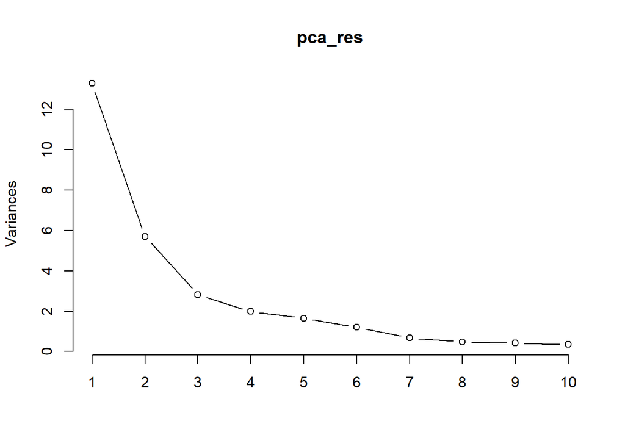

```r
pca_res <- prcomp(nndata[,2:ncol(nndata)], center = TRUE, scale = TRUE)
plot(pca_res, type="l")
```

## To visualize which variable are the most influential on the first 2 components

[figure not shown]

```r
library(ggfortify)
## Loading required package: methods
autoplot(pca_res, data = nndata,  colour = 'diagnosis',
                    loadings = FALSE, loadings.label = TRUE, loadings.colour = "blue")
```

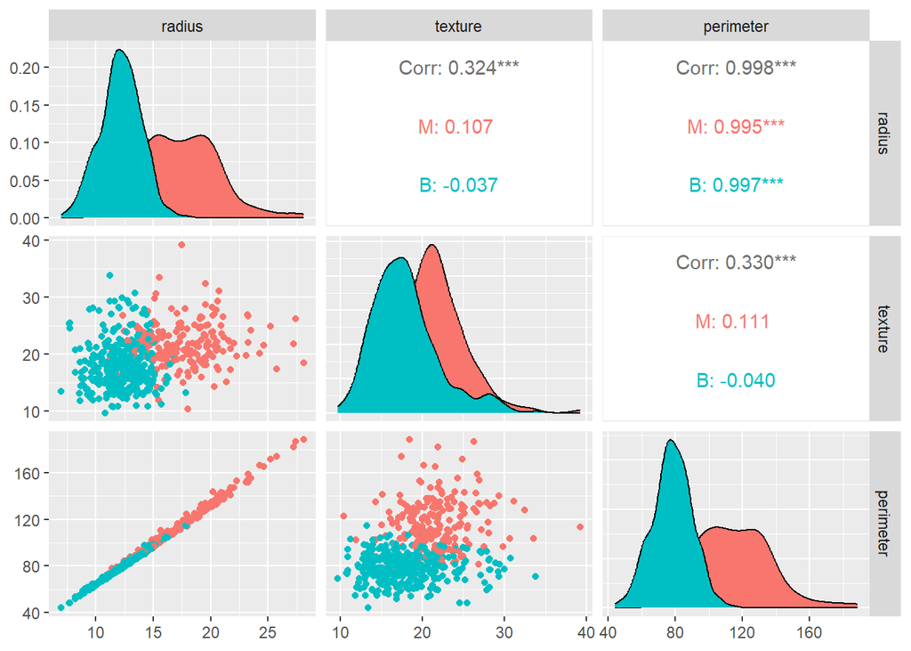

```r
pcs3 <- cbind(as_tibble(nndata$diagnosis), as_tibble(pca_res$x))
GGally::ggpairs(nndata, columns = 2:4, ggplot2::aes(color = diagnosis))
```